# Disease dynamics

Sebastian Schreiber

July 14, 2015

These notes are the basis of the lectures that I give as part of the “Mathematical Modeling of Biological Systems” Cluster of the UC Davis COSMOS program. This cluster is currently run by Tim Lewis, Bob Guy, and myself. My lectures cover evolutionary game theory and disease dynamics.

# Introduction

**See lecture slides** for introduction to epidemiology.

According H. Shodell (Science 1982, September, p. 50)

> Epidemiologists are like bookies of disease, stalking the globe to determine point-spreads on which groups of people are most likely to get which diseases.Part detective and part statistician, part anthropologist and part physician, epidemiologists hope to track down the agents of illness by deducing which of the differences between peoples lie at the root of their distinctive disease patterns.

## $R_0$ and controlling outbreaks

**See lecture slides** for introduction to $R_0$ and play video clip starting at 17:30 about $R_0$ from Contagion.

According the Center for Disease Control (CDC)

> Measles is highly contagious and can be spread to others from four days before to four days after the rash appears. Measles is so contagious that if one person has it, 90% of the people close to that person who are not immune will also become infected with the measles virus.

**If an individual has a contact rate of approximately 2 individuals per day, what is R0 for measles?**

## Herd immunity

Given that that whether $R_0>1$ or $<1$ determines whether a disease is likely to give rise to a major outbreak, finding means and methods to reduce $R_0$ to $<1$ has been an important focus of epidemiology. Finding vaccines is one such method. Under ideal conditions, these vaccines ensure the individuals are no longer susceptible to the disease and, thereby, reduce the reproductive number of the disease.

Suppose that a fraction $v$ of the population has been vaccinated for a disease whose reproductive number is $>1$ in the absence of the vaccine. **Determine how effective the vaccine needs to be in order to prevent major outbreaks.** **Answer:** Since the susceptible pool is reduced by fraction $1-v$, the post-vaccination reproductive number is $(1-v)R_0$. We want $(1-v)R_0<1$. Equivalently, $v>1-1/R_0$. As $R_0>1$, the critical vaccination threshold is less than $1$ i.e. less than $100\%$. Not all individuals need to be vaccinated to prevent major outbreaks. Hence, provided enough folks are vaccinated, they protect the rest of the population for exposure to disease. This effect is called *herd immunity*: vaccinating a fraction of the herd, protects the rest of the herd.

**For the following diseases, compute the critical $v$ values.**

| Disease | Transmission | $R_0$ | Threshold |
| --- | --- | --- | --- |
| Diphtheria | Saliva | 6-7 | **?** |
| Measles | Airborne | 12-18 | **?** |
| Mumps | Airborne droplet | 4-7 | **?** |
| Pertussis | Airborne droplet | 12-17 | **?** |
| Polio | Fecal-oral route | 5-7 | **?** |
| Rubella | Airborne droplet | 5-7 | **?** |
| Smallpox | Social contact | 6-7 | **?** |

Discuss voluntary vaccinations and the following quote from Wikipedia:

> 1998 publication of a fraudulent research paper in the medical journal The Lancet that lent support to the subsequently discredited theory that autism could be caused by MMR vaccine. Andrew Wakefield had multiple undeclared conflicts of interest, had manipulated evidence, and had broken other ethical codes. The Lancet paper was fully retracted in 2010, and Wakefield was found guilty by the General Medical Council of serious professional misconduct in 2010. Former Playmate of the Month and comedy TV star, Jenny McCarthy, wrote a book about her son’s apparent autism, and her belief the preservative in the MMR jab had caused it.

**See lecture slides for discussion on smallpox**

## Ebola

The Ebola virus causes an acute, serious illness which is often fatal if untreated. Ebola virus disease (EVD) first appeared in 1976 in $2$ simultaneous outbreaks in Sudan and the Democratic Republic of Congo. The latter occurred in a village near the Ebola River, from which the disease takes its name. Ebola spreads by direct contact with body fluids, such as blood, of an infected individual. Human mortality rate ranges between $25$ and $90$ percent. According the World Health Organization (April 2015), there are “currently no licensed Ebola vaccines but two candidates are undergoing evaluation.” It is thought that fruit bats are natural Ebola virus hosts and is introduced into the human population through close contact with the blood, secretions, organs or other bodily fluids of infected bats and other animals such as chimpanzees, gorillas, monkeys, forest antelope and porcupines.

The current outbreak in West Africa is the largest and most complex Ebola outbreak since the Ebola virus was first discovered in 1976. On August 8, the WHO Director-General declared the West Africa outbreak a Public Health Emergency of International Concern under the International Health Regulations. There have been more cases and deaths in this outbreak than all others combined.

According to the Center for Disease Control (CDC), the incubation period 2-21 days, and the infectious period $6$ days. Studies have estimated that the contact rate is $1.14$/day during the infectious period for individuals being treated by members of their community. In contrast, the contact rate is $4.56$/day for hospitalized individuals. In community care, transmission probability is $0.16$, but for hospitals observing the appropriate protocols, the transmission probability is only $0.01$. The mortality rate in either situation is approximately $70\%$. Deaths in community care often receive “unsecured burials” which last two days and lead to a $6.8$ per day contact rate with the infectious body.

**What is $R_0$ for non-hospitalized individuals? hospitalized individuals?**

**What percentage of infected individuals need to be hospitalized to prevent outbreak?**

**Compare your prediction with what the CDC found** [here](http://www.cdc.gov/vhf/ebola/outbreaks/2014-west-africa/qa-mmwr-estimating-future-cases.html) **using more sophisticated methods.**

## Dengue

*Upcoming*

# Disease dynamics

## SIR model

To describe the *dynamics* of a disease as it propagates through a population, we begin with a basic discrete time model where individuals are either susceptible (S), infected and infectious (I), or removed (R) from the susceptible and infectious pool of individuals. Removal may correspond to individuals recovering and becoming immune to reinfection, or individuals die. In either case, these individuals are not contributing the disease dynamics.

Let $S_t$, $I_t$, and $R_t$ denote the number of susceptible, infected and removed individuals at time $t$ e.g. day $t$. We will focus on diseases where the population size (including possibly dead individuals) is relatively constant. In particular, we will (for now) ignore births and deaths due to other sources of mortality. This assumption is reasonable when we are interested in the outbreak dynamics of a disease with short infectious period relative to a human (or more generally host) lifespan. Let $N=S_t+I_t+R_t$ be the total population size.

Assume that each susceptible individual encounters individuals randomly at a rate $c$ (the contact rate) and $p$ is the probability there is a successful transmission event following an encounter with an infected individual. As the probability that a randomly encountered individual is infected is $I/N$, the rate at which a susceptible individual encounters infected individuals and gets infected is $pcI/N$. Under these assumptions, one can show (see challenge exercise below) that the probability of a susceptible individual “escaping” infection from time $t$ to $t+1$ is $\exp(-pc I_t/N)$. Lets also assume that a fraction $\gamma$ of infected individuals are removed at the end of each day. **Under this set of assumptions, write down a model of the SIR dynamics** You should get the following (**be sure you understand why!!**) $\begin{aligned} S_{t+1}&=S_t \exp(-\beta I_t/N)\\ I_{t+1}&=S_t(1-\exp(-\beta I_t/N))+(1-\gamma)I_t\\ R_{t+1}&=R_t+\gamma I_t \end{aligned}$ where $\beta=pc$.

Before we try to analyze this model by relating it to our $R_0$ work, lets try simulating it!. The following code is a simulator that plots the SIR dynamics as a function of time $t$.

```r
SIR=function(beta,gamma,N,I0,S0,T){
 S=matrix(NA,T,length(I0))
 S[1,]=S0
 I=matrix(NA,T,length(I0))
 I[1,]=I0
 for(t in 1:(T-1)){
   S[t+1,]=S[t,]*exp(-beta*I[t,]/N)
   I[t+1,]=S[t,]*(1-exp(-beta*I[t,]/N))+(1-gamma)*I[t,]
 }
 R=N-S-I
 par(cex.axis=1.5,cex.lab=1.5)
 matplot(S,type="l",col="green",xlab="days",bty="n",ylab="abundances",lwd=2,ylim=c(0,N))
 matplot(I,type="l",col="red",add=TRUE,lwd=2)
 matplot(R,type="l",col="black",add=TRUE,lwd=2)
 legend("right",c("Susceptible","Infected","Recovered"),lty=1,col=c("green","red","black"),bty="n",cex=1.5,lwd=2)
}
```

Let runs this code using parameters consistent with measles from our earlier discussion. As measles lasts about $10$ days, we can set $\gamma=1/10$ i.e. there is a $1/10$th chance per day that an infected individual recovers and, consequently, on average an individual remains infected for $10$ days. For the contact rate $\beta$, we will use $1.2$. Assuming a small population size of $1000$ individuals with one infected individual, we get the following dynamics

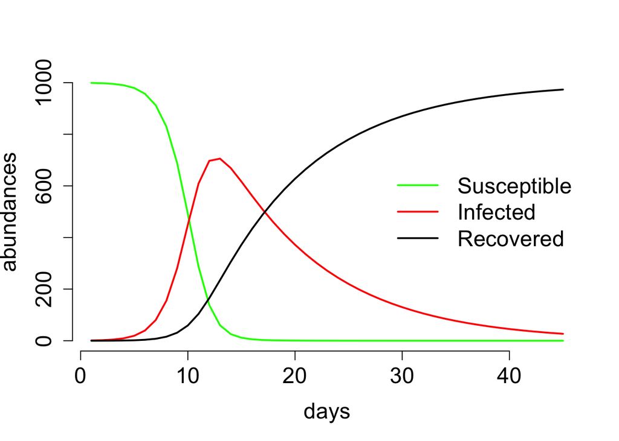

```r
SIR(beta = 1.2,gamma = 0.1,I0 = 1,S0=999,N=1000,T=45)
```

Now lets change the model run by assuming that initially 95% of the population is vaccinated for measles (i.e. removed) and $1$ person is infected.

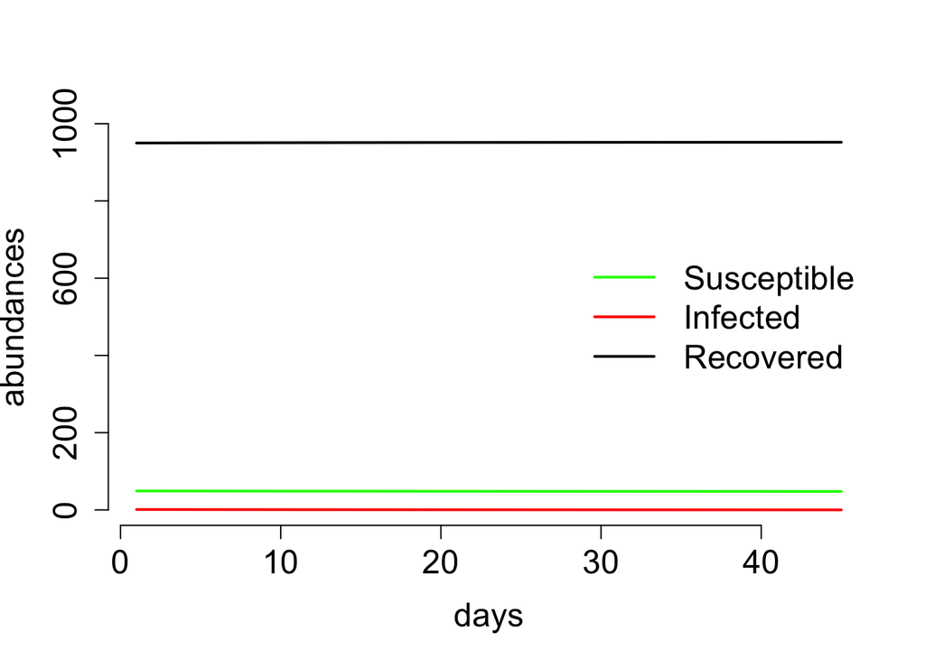

```r
SIR(beta = 1.2,gamma = 0.1,I0 = 1,S0=49,N=1000,T=45)
```

In this case there is no outbreak. *Why the difference?*

To get at this question and link back to our discussion about $R_0$, we will do some analysis. Recall, an equilibrium $(S^*,I^*,R^*)$ is an initial condition for the model such that $S_t=S^*,I_t=I^*,R_t=R^*$ implies that $S_{t+1}=S^*,I_{t+1}=I^*,R_{t+1}=R^*$ i.e. the abundances do not change over time. **What are the equilibria of the model?** A little thought reveals that they are all of the form $S=S^*,I=0,R=N-S^*$ for any $S^*$ between $0$ and $N$. In other words, an initial condition without the disease is an equilibrium.

Now, lets consider the dynamics of $I_t$ when the population is near a disease free equilibrium $S_t\approx S^*,I_t\approx 0,R_t\approx N-S^*$. Recall from calculus, $1-\exp(-x)\approx x$ for $x$ sufficiently small. Hence, $1-\exp(-\beta I_t/N)\approx \beta I_t/N$ for $I_t\approx 0$ and $I_{t+1}\approx S^* \beta I_t/N +(1-\gamma)I_t=(\beta S^*/N+1-\gamma)I_t$ But this is the linear population growth model that Tim Lewis told you about. Hence, the infected would tend to grow if and only $\beta S^*/N+1-\gamma>1$. Equivalently $(\beta S^*/N)/\gamma>1$. **But what is $(\beta S^*/N)/ \gamma$?** Well, $1/\gamma$ is the mean duration of the infectious period and $\beta S^*/N$ is the number of people infected per day of the infectious period when near the equilibrium $S^*,0,N-S^*$. **Hence, $(\beta S^*/N)/\gamma$ is $R_0$!!!**

# Disease spread on networks

The models we have discussed thus far assume that (i) populations are sufficiently large that you can treat them as a continuum, (ii) the dynamics are entirely deterministic, and (iii) individuals encounter one another randomly in the same manner. Here, we relax all of these assumptions by examining disease dynamics on finite networks of individuals. We will use these models to understand how network structure influences the likelihood of a disease outbreak, and how we can take advantage of network structure to reduce this likelihood.

## Random Graphs

We will model social networks using *graphs* that consist of a finite collection $V$ of *vertices* (e.g. individuals) numbered $1,2,\dots,n$ and a finite collection $E$ of *edges* (e.g. pairs of individuals that interact) which consist of pairs of vertices i.e. $(a_1,b_1),(a_2,b_2),\dots...$ where $a_i,b_i\in \{1,\dots,N\}$. In R, we can work with graphs using the igraph package:

```r
library(igraph)
```

One simple type of graph is a ring graph e.g. a ring of friends. For a ring graph with $n$ vertices, we have the edges are given by $(1,2),(2,3),\dots,(n-1,n),(n,1)$. We can create and plot a ring graph as follows:

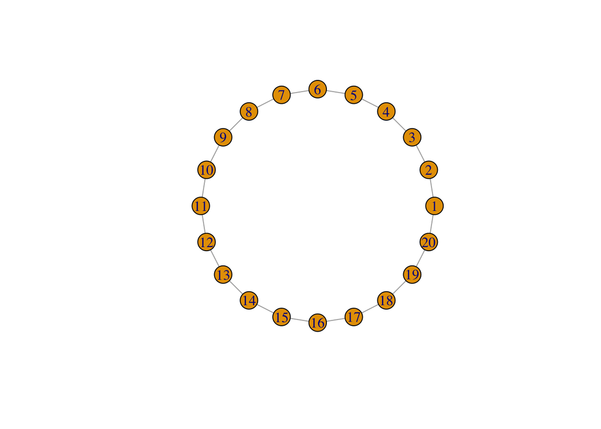

```r
g=make_ring(n=20)
g$layout=layout.circle
plot(g)
```

Alternatively, we could have all $n=20$ individuals know each other ($(i,j)$ is an edge for every $i\neq j$) in which case we have a *fully connected* graph.

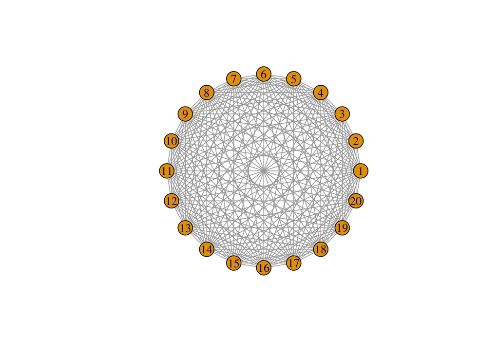

```r
g=make_full_graph(n=20)
g$layout=layout.circle
plot(g)
```

We can also create graphs randomly by having a probabilistic rule that determines whether any pair of vertices has an edge connecting them. The most classic example of a random graph is Erdos-Renyi graph in which each possible edge occurs with probability $p$.

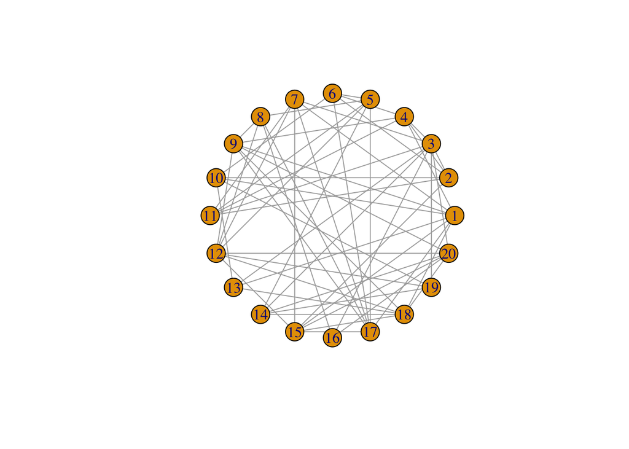

```r
g=erdos.renyi.game(n=20,p=0.3)
g$layout=layout.circle
plot(g)
```

A more recent random graph is the “small-world” graphs introduced by Duncan Watts and Steven Strogatz. The simplest version of these graphs ($1$-dimensional) correspond to rewiring (with probability $p$) edges in a circular graph where individuals are connected to their nearest $k$ neighbors.

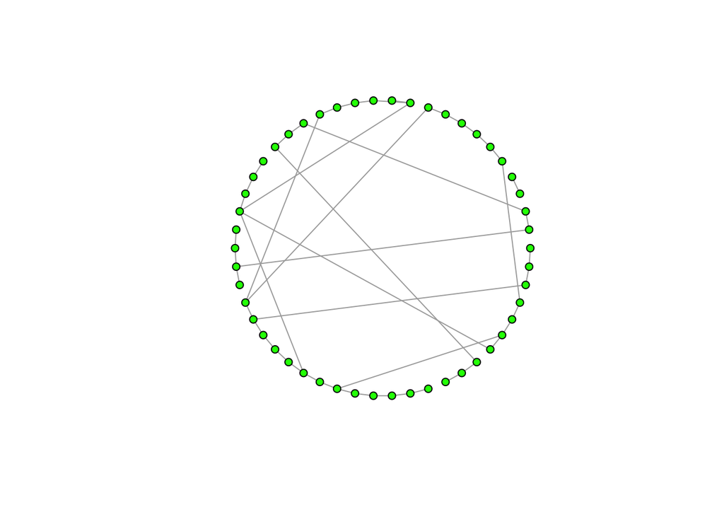

```r
g=watts.strogatz.game(dim=1,size=50,nei=1,p=0.1)
g$layout=layout.circle
plot(g,vertex.size=5,vertex.color="green",vertex.label=NA)
```

From a disease spread perspective, a key quantity associated with the vertices of these graphs is the *degree of a vertex*–the number of edges eminating from the vertex. Biologically, the degree of an vertex corresponds to the number of individuals this individual might infect if they were infected. For example, **what are the degree of vertices in the circle graph? the fully connected graph? what is the expected degree of a vertex in an Erdos-Renyi graph? the watts-strogatz graph from above?**

**Answers:** degree of all vertices is $2$ in the circle graph, and $n-1$ in the full connected graph. The expected degree of any vertex in the Erdos-Renyi graph is $p(n-1)$, and $2\times k$* in the Watts-Strogatz graph.

If we know the degree of every vertex, then we also know the *degree distribution*: the probability distribution $p_0,p_1,\dots,p_{n-1}$ where $p_i$ is the fraction of vertices with degree $i$. The degree distributions for the circle and full connected graphs are quite uninteresting i.e. $p_2=1$ and $p_i=0$ for $i\neq 2$ in the circle graph, and $p_{n-1}=1$ and $p_i=0$ for $i\neq n-1$ in the full connected graph. In our random graphs, however, the degree distribution are (with probability one) more interesting. We can compute them directly using the degree.distribution command from the igraph package. For example,

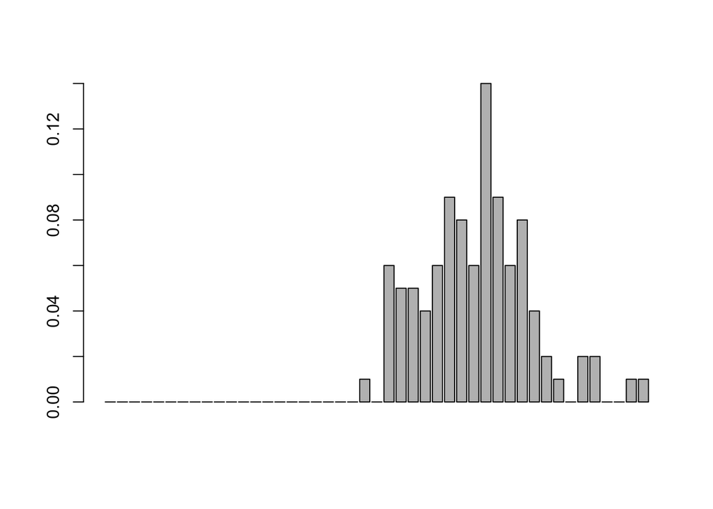

```r
g=erdos.renyi.game(n=100,p=0.3)
barplot(degree.distribution(g))
```

Two important statistics associated with the degree distribution are its mean and variance. The mean, as we have discussed before, is given by $M=p_1+2p_2+3p_3+\dots (n-1)p_{n-1}$ $M$ corresponds to the expected number of individuals a randomly choosen individual could infect if they were infected. The variance, on the other hand, describes how much variation there is around the mean and is given by $V=p_0(M-0)^2+p_1(M-1)^2+p_2(M-2)^2+\dots p_{n-1}(M-n+1)^2$ **What is the mean and variance of the degree distribution for the ring graph? What is it for a realization of an Erdos-Renyi graph with $n=1000$ vertices and $p=2/n$?**

**Answer:** For the ring graph, $M=2$ and $V=0$. For a realization of the Erdos-Renyi graph we get

```r
g=erdos.renyi.game(n=1000,p=2/1000)
M=mean(degree(g))
M
```

```
## [1] 2.148
```

```r
V=mean((degree(g)-M)^2)
V
```

```
## [1] 2.168096
```

So we get a mean and variance of about $2$. Indeed, one can prove mathematically, that for an Erdos-Renyi graph with $p=k/n$, the mean and variance approach $k$ as $n\to \infty$ with probability one. Kinda cool!

## Disease dynamics on graphs

Now lets imagine that our graph consists of individuals that can be in one of three states: susceptible, infected, or removed. At each time step, each infected individual infects any susceptoble individual they are connected to with probability $q$, and then becomes a removed indivivual. Repeating this dynamic leads to a stochastic process on the graph that ultimates halts when there are no more infected individuals on the graph. The following code can be used to simulate the dynamics. The input for this function is

g - a graph q - the probability an infected individual infects a neighbor case.zero - which individual is initially infected control - which subset of individuals are vaccinated plot.method - 1 fruchterman.reingold, 2 circle (default) size - size of the plotted vertices (default 10)

**Note:** The code produces an animation which you can only see if you run it on $R$ directly. In this document, you will only see the final state of the graph and the dynamics of susceptible and infected as a fuction of disease generations.

```r
outbreak=function(g,q=0.75,case.zero=1,control=c(),plot.method=2,size=10){
    A=as.matrix(get.adjacency(g))
    n=dim(A)[1]

    # initial states of all individuals:
    # 0 susceptible, 1 infected, 2 recovered
    s="green"
    i="red"
    r="black"
    States=matrix(s,n,1)
    States[case.zero]=i
    States[control]=r

    # probability of infecting your neighbor
    p.infect=q

    # number of individuals in each class
    I=c(1)
    R=c(length(control))
    S=c(n-I-R)
    All=States



    while(length(which(States==i))>0){
        who=which(States==i)
        if(length(who)>0){
            for(q in 1:length(who)){
            friends=which(A[who[q],]==1)
            susceptible=which(States[friends]==s)
            k=length(susceptible)
            if(k>0){
                change=rbinom(k,1,p.infect)
                States[friends[susceptible[which(change==1)]]]=i
            }
        }
    States[who]=r
    }
    I=c(I,length(which(States==i)))
    S=c(S,length(which(States==s)))
    All=cbind(All,States)
    }

    T=dim(All)[2]
    g=graph.adjacency(A,mode="undirected")
    V(g)$color=All[,1]
    if(plot.method==1){
        g$layout=layout.fruchterman.reingold
        L=layout.fruchterman.reingold(g)
        }
    if(plot.method==2){
        g$layout=layout.circle
        L=layout.circle(g)
    }
        B=plot.igraph(g,vertex.label=NA,vertex.size=size,layout=L)
        for(t in 1:T){
        g2=graph.adjacency(matrix(0,100,100),mode="undirected")
        V(g2)$color=All[,t]
        g2$layout=g$layout
        plot(g2,vertex.label=NA,add=TRUE,vertex.size=size,edge.width=0,layout=L)
        Sys.sleep(0.5)
        }

    #cat("\n","Enter 1 to plot time series:")
    #y=scan(n=1,quiet=TRUE)
    y=1
    if(y==1){
    par(cex.lab=1.5,cex.axis=1.5)
    plot(100*S/n,type="b",bg="green",lwd=3,pch=21,cex=2,ylim=c(0,100),xlab="generations",ylab="percentage")
    points(100*I/n,type="b",bg="red",lwd=3,pch=21,cex=2)
    legend("topright",c("susceptible","infected"),pch=21,pt.bg=c("green","red"),bty="n",cex=1.5)
    }


}
```

**Run outbreaks for a ring graph with 50 individuals and $p=0.9$, and a Erdos-Renyi graph $n=50$, $p=2/50$, and $p=0.9$. Compare what you find with your neighbors and discuss.**

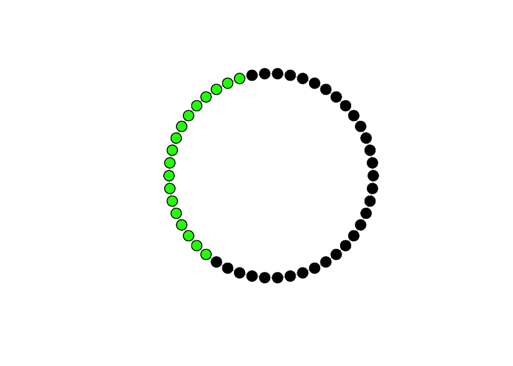

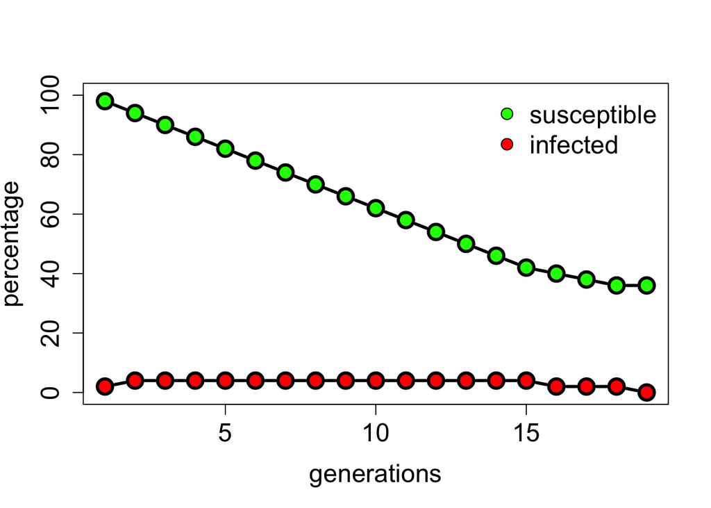

```r
g1=make_ring(50)
outbreak(g=g1,q=0.9)
```

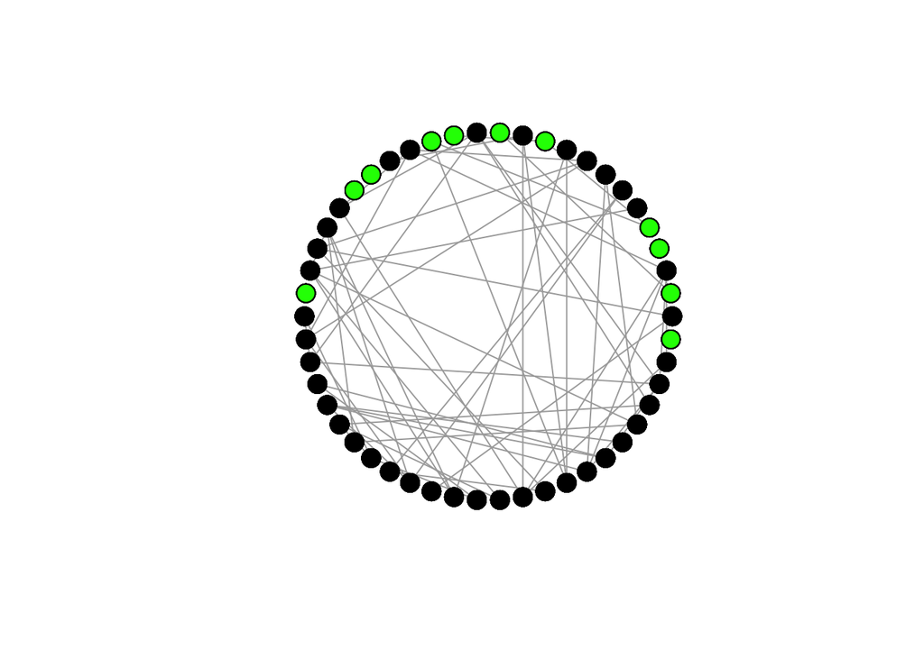

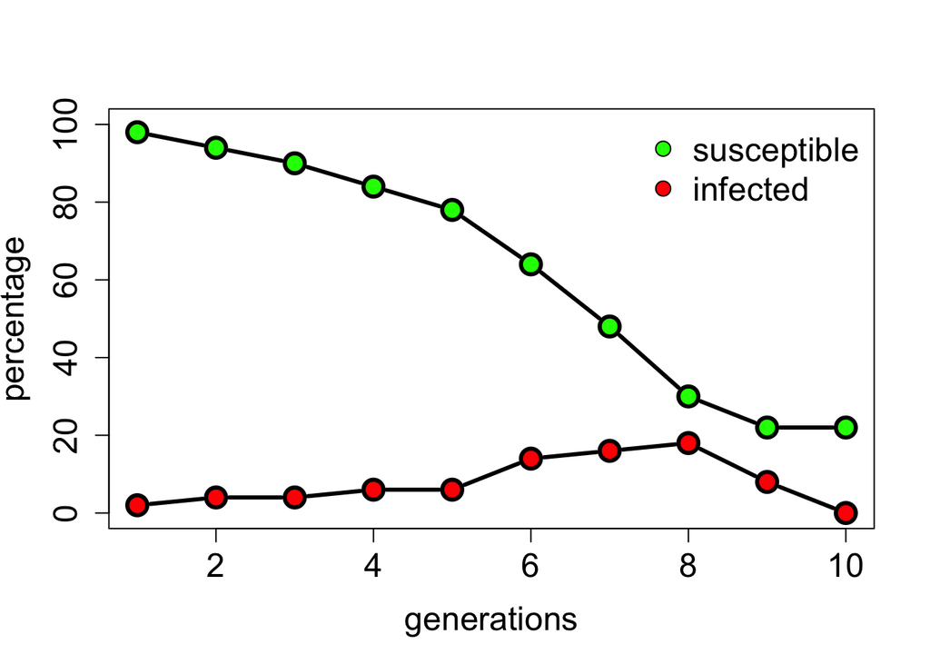

```r
g2=erdos.renyi.game(50,2/50)
outbreak(g2,q=0.9)
```

**Answer:** In the ring graph, the disease sometimes propagates along the ring but usually dies out early. In the random graph, the disease sometimes gives rise to large outbreaks and sometimes dies out.

*What is going on?* Lets try to identify $R_0$ for these dynamics. It is tempting to simply define it as the expected number of friends of a randomly choosen individual times the probability of transmitting to each friend i.e. $qM$. However, this turns out not to be appropriate for two reasons. First, for all but the first infected individual, infected individuals were infected by someone else in the network and they con not reinfect them. This would suggest that we might want to use $a(M-1)$ for $R_0$. Turns out this isn’t quite right either as individuals with many friends are more likely to get infected than individuals with few friends. And these individuals once infected will infect many others. With this in mind, we might ask for a randomly infected individual how many others do we expect them to infect in a largely susceptible population? **How might you compute this quantity?**

**Answer:** All else being equal, individuals with degree $k$ are $k$ times more likely to get infected than individuals with degree $1$. More generally, the degree of an infected individual is proportional to $k$. As the total number of degree $k$ individuals is proportional to $p_k$, we get that the probability of an infected individual being degree $k$ is propostional to $kp_k$. What is the proportionality constant? Well, we need the sumof these numbers to be one. Hence, it is $M=\sum_k k p_k$. The expected number of individuals a degree individual will infect is $p(k-1)$. Hence, we might define $R_0$ as $R_0=\sum \frac{k p_k}{M}q(k-1)=qM(1+V/M^2)-q$ So we get something close to $q(M-1)$ but there is an extra term $qV/M^2$. This term $V/M^2$ correspnds to the squared *coefficient of variation* where the *coefficient of variation* measures the variation around the mean relative to the mean. Hence, variation in degree can increase the $R_0$ associated with a graph.

Use the following R command to compute $R_0$ for the two graphs that we simulated the disease dynamics on. **What do you find?**

```r
R0=function(g,q){
  d=degree(g)
    v=d/sum(d)
    R0=q*(sum(v*d)-1)
    return(R0)
}
```

**Answer:**

```r
R0(g1,0.9)
```

```
## [1] 0.9
```

```r
R0(g2,0.9)
```

```
## [1] 1.891525
```

Hence, even though the (expected) means for both of these graphs is $2$, the $R_0$ is much larger in the random graph due to the variation in the degree. This variation is allowing for the outbreaks that we see in these random graphs.

Now suppose we wanted to prevent future outbreak in the random graph but only could vaccinate, say 20%, of the individuals. **If we vaccinated the individuals randomly, what would $R_0$ become for your graph? How might we vaccinate more effectively?**

**Answer** If we just vacinnate randomly, then we would expect a 20% reduction in $R_0$.